# GAMLSS modelling in mgcv and mgcViz

Matteo Fasiolo

October 17 2023

# Body mass index modelling

Simple data set on BMI vs age:

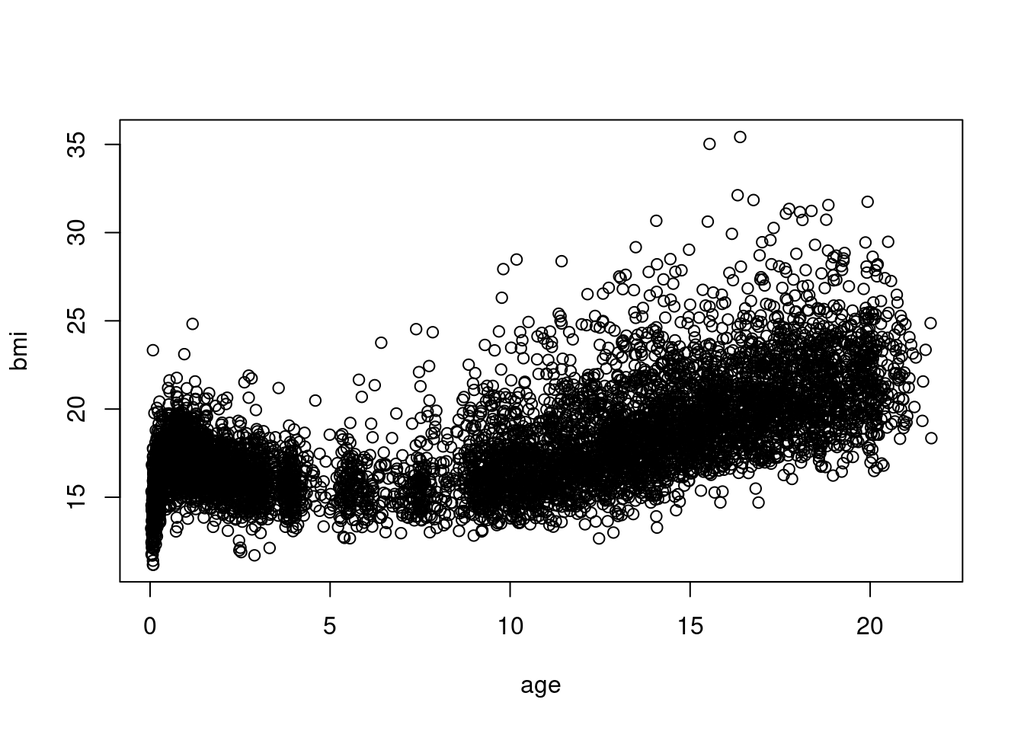

```r
library(testGam)
data(dbbmi)

plot(bmi ~ age, data = dbbmi)
```

Get subset to speed up computation:

```r
set.seed(151)
dbbmi <- dbbmi[sample(1:nrow(dbbmi), 2000), ]
dbbmi <- dbbmi[order(dbbmi$age), ]
```

We fit a standard Gaussian GAM:

```r
library(mgcViz)
fit1 <- gamV(bmi ~ s(age, bs = "ad", k = 20),
             data = dbbmi,
             aViz = list(nsim = 50))
```

The mean bmi vs age looks right:

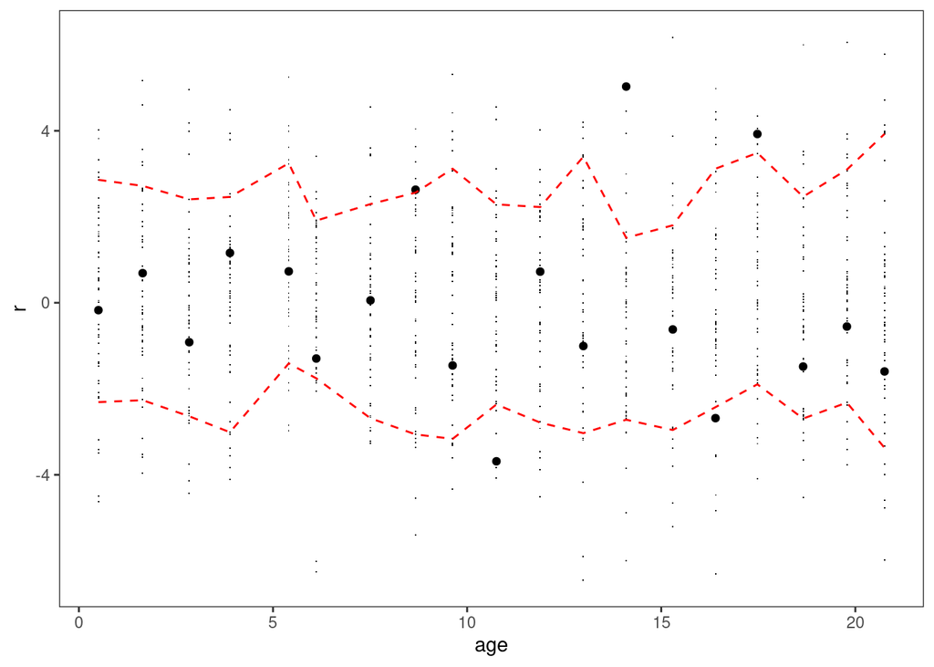

```r
check1D(fit1, "age") + l_gridCheck1D()
```

Now we check the residuals standard deviation along `age`:

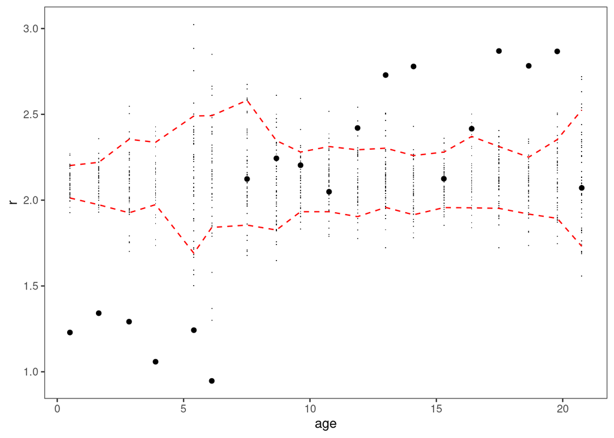

```r
check1D(fit1, "age") + l_gridCheck1D( sd )
```

The variance is clearly increasing. We take this into account using a `shash` model

```r
fit2 <- gamV(list(bmi ~ s(age, bs = "ad", k = 20), # Location
                      ~ s(age), # Scale
                      ~ 1,      # Skewness
                      ~ 1),     # Kurtosis
             data = dbbmi,
             family = shash,
             aViz = list(nsim = 50))
```

and we repeat the check and check also for skewness

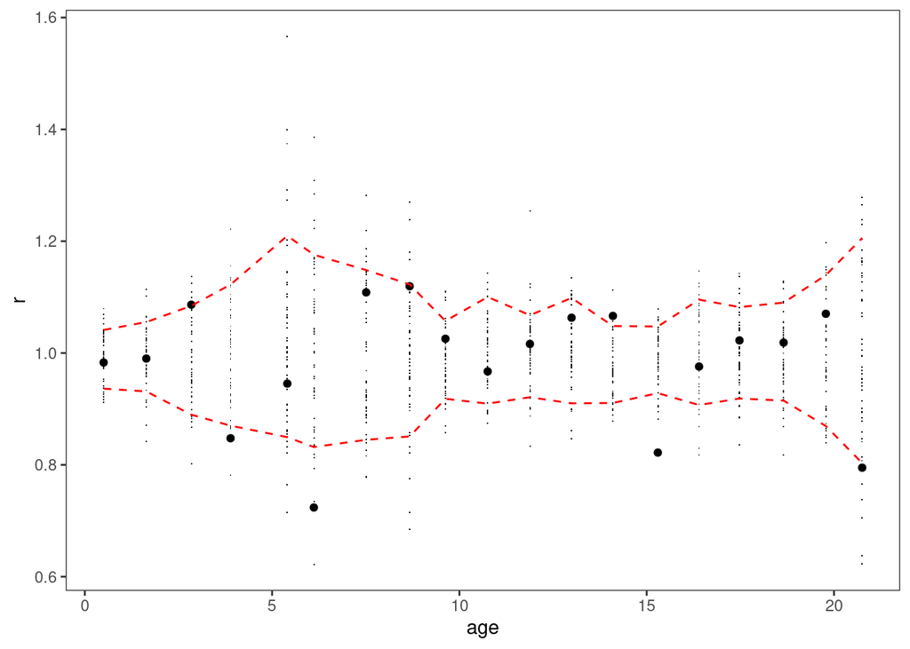

```r
check1D(fit2, "age") + l_gridCheck1D( sd )
```

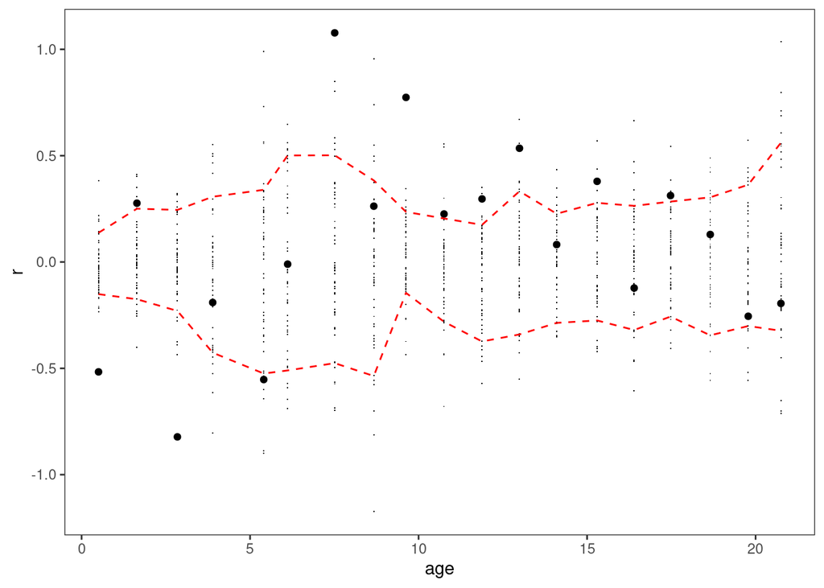

```r
library(e1071)
check1D(fit2, "age") + l_gridCheck1D( skewness )
```

Model the skewness as well

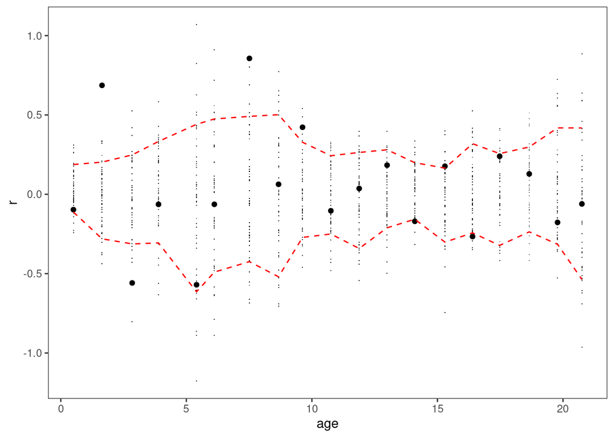

```r
fit3 <- gamV(list(bmi ~ s(age, bs = "ad", k = 20), ~ s(age), ~ s(age), ~ 1),
             data = dbbmi,
             family = shash,
             aViz = list(nsim = 50))

check1D(fit3, "age") + l_gridCheck1D( skewness )
```

Plot effects:

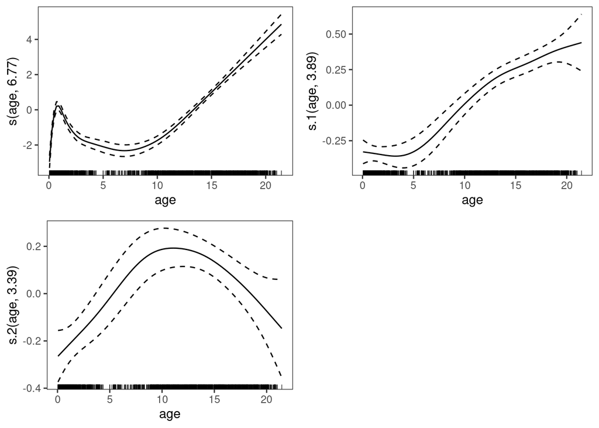

```r
print(plot(fit3), pages = 1)
```

Plot quantiles:

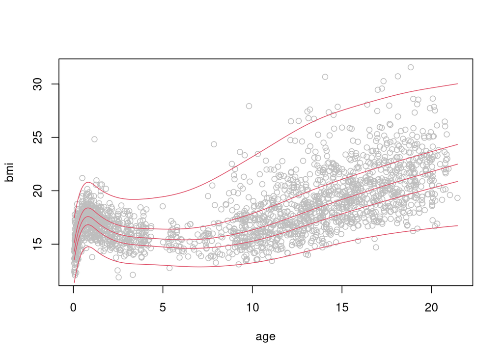

```r
plot(bmi~age, data=dbbmi, col = "grey")
pr <- predict(fit3)
for(.q in c(0.01, 0.25, 0.5, 0.75, 0.99)){
  q_hat <- fit3$family$qf(.q, pr)
  lines(dbbmi$age, q_hat, col = 2)
}
```

# Multivariate modelling of the GEFCom14 electricity demand data

Load data and have a look at it

```r
library(SCM)
library(mgcViz)

data(GEF14_d4)
print(head(GEF14_d4[ , c("year", "doy", "dow", "load_h17", "load_h20", "load24_h17",
                         "load24_h20", "temp_h17", "temp_h20")]), digits = 2)
```

```
##   year doy dow load_h17 load_h20 load24_h17 load24_h20 temp_h17 temp_h20
## 1 2005   3   1      102       95        108         99      8.8      7.2
## 2 2005   4   2       94       80        102         95     13.6     13.8
## 3 2005   5   3       84       70         94         80     16.0     14.3
## 4 2005   6   4       86       74         84         70     14.0     14.9
## 5 2005   7   5       82       67         86         74     17.4     16.2
## 6 2005   8   6      108       91         82         67     10.4     10.6
```

Fit a bivariate Gaussian GAM:

```r
fit1 <- gam_scm(list(load_h17 ~ dow + s(doy, k = 15) + load24_h17 + s(temp_h17),
                     load_h20 ~ dow + s(doy, k = 15) + load24_h20 + s(temp_h20)),
                family = mvn_scm(d=2),
                data = GEF14_d4)
fit1 <- getViz(fit1, nsim = 25)
```

Plot the fitted effects:

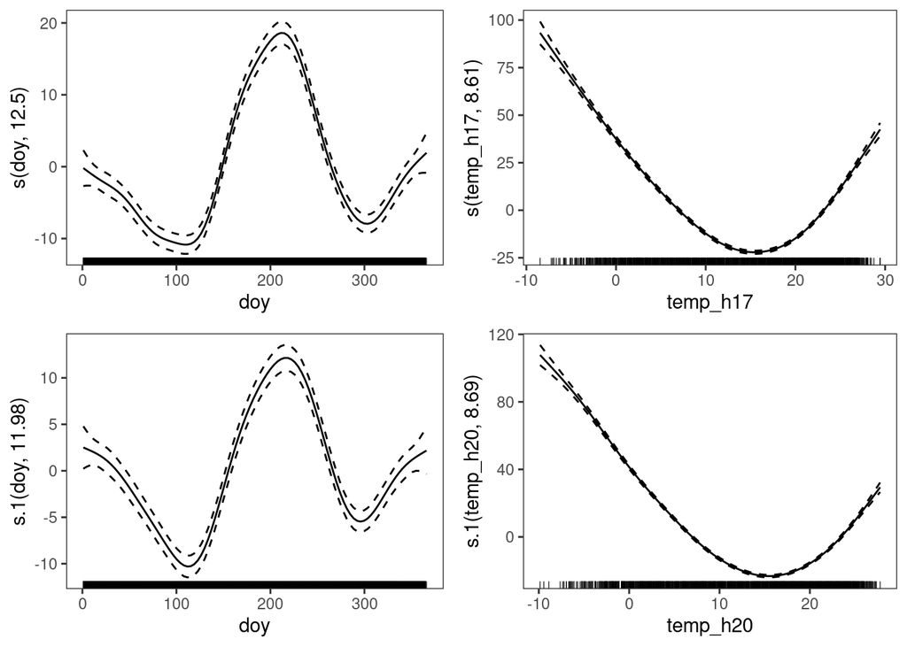

```r
print(plot(fit1), pages = 1)
```

Get predicted mean vector and covariance matrix:

```r
pred <- predict(fit1, type = "response")
head(pred)
```

```
##        [,1]      [,2]     [,3]     [,4]      [,5]
## 1 116.13400 110.24338 90.06975 76.46085 0.8925699
## 2 104.77969  90.92676 90.06975 76.46085 0.8925699
## 3 101.63547  86.75085 90.06975 76.46085 0.8925699
## 4  98.92001  83.00367 90.06975 76.46085 0.8925699
## 5 100.86489  84.69628 90.06975 76.46085 0.8925699
## 6 108.97419  91.40228 90.06975 76.46085 0.8925699
```

Does the variance change with `doy`?

```r
check1D(fit1, "doy") + l_gridCheck1D(gridFun = function(.x){
  sd(.x[ , 1])
 }
)
```

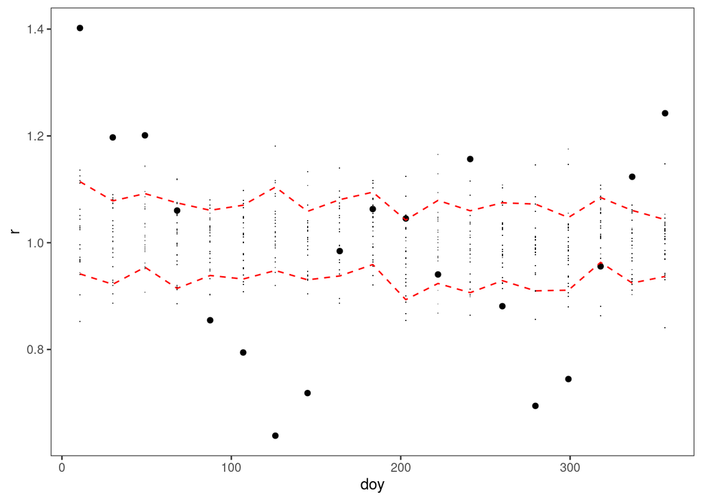

Does the correlation change with `doy`?

```r
check1D(fit1, "doy") + l_gridCheck1D(gridFun = function(.x){
  cor(.x[ , 1], .x[ , 2])
 }
)
```

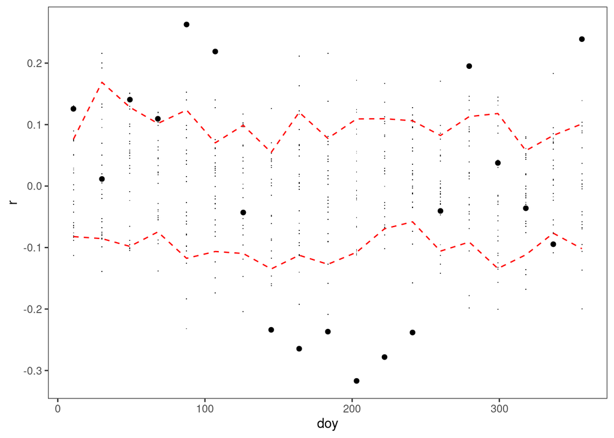

Model the covariance (its MDC parametrisation) using `doy`:

```r
fit2 <- gam_scm(list(load_h17 ~ dow + s(doy, k = 15) + load24_h17 + s(temp_h17),
                     load_h20 ~ dow + s(doy, k = 15) + load24_h20 + s(temp_h20),
                     Th_11 ~ s(doy),
                     Th_22 ~ s(doy),
                     Th_12 ~ s(doy)),
                family = mvn_scm(d=2), data = GEF14_d4)
fit2 <- getViz(fit2, nsim = 25)
```

Repeat the checks:

```r
check1D(fit2, "doy") + l_gridCheck1D(gridFun = function(.x){
  sd(.x[ , 1])
 }
)
```

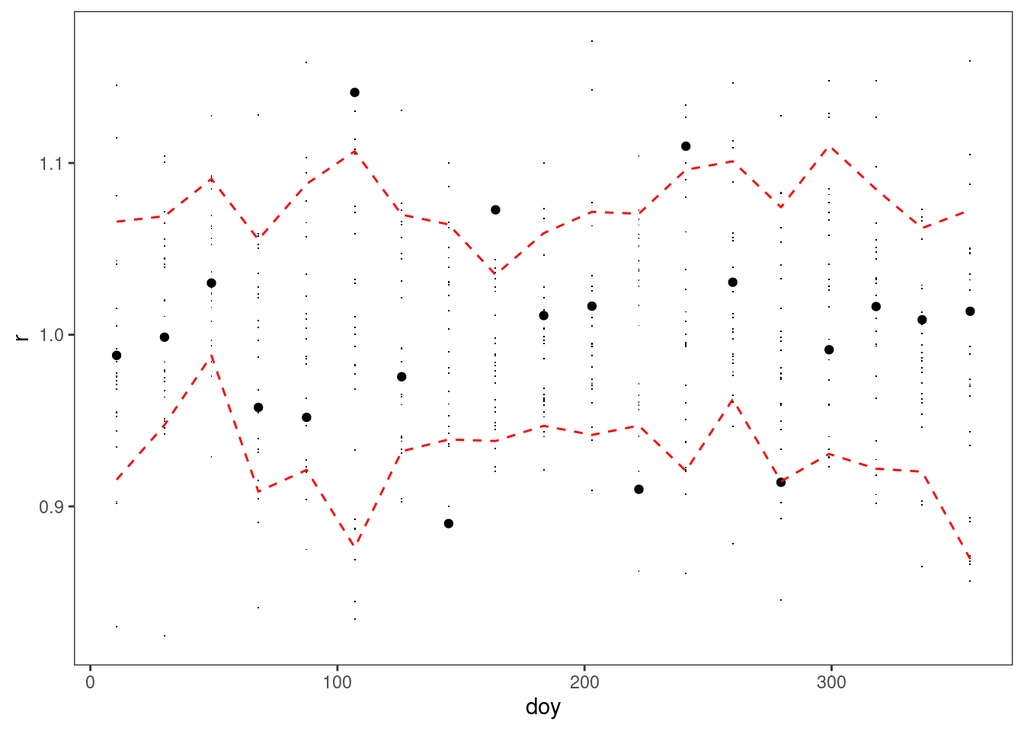

```r
check1D(fit2, "doy") + l_gridCheck1D(gridFun = function(.x){
  cor(.x)[1, 2]
 }
)
```

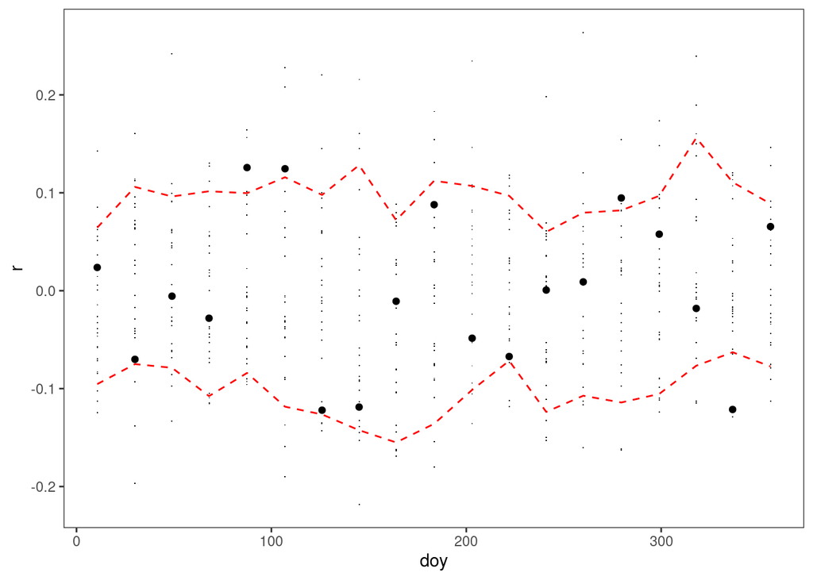

How to visualise effects on the covariance?

```r
preds <- predict(fit2, type = "response")
head(preds)
```

```
##       [,1]      [,2]     [,3]     [,4]      [,5]
## 1 115.6868 110.01875 247.2743 218.6821 0.9458239
## 2 106.2379  93.13885 241.0683 213.9098 0.9443199
## 3 103.1429  88.30167 235.0290 209.2688 0.9427806
## 4 100.2114  85.27921 229.1581 204.7607 0.9412071
## 5 103.4726  87.54335 223.4579 200.3878 0.9396011
## 6 108.4219  91.37769 217.9312 196.1527 0.9379647
```

Look at accumulated local effects (ALEs) of `doy` on load variance at 5pm:

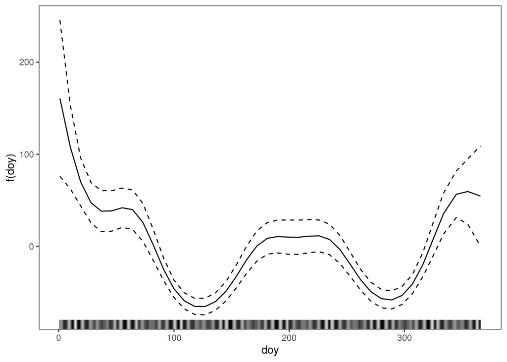

```r
plot(ALE(fit2, oind = 3, x = "doy", type = "response"))
```

and correlation:

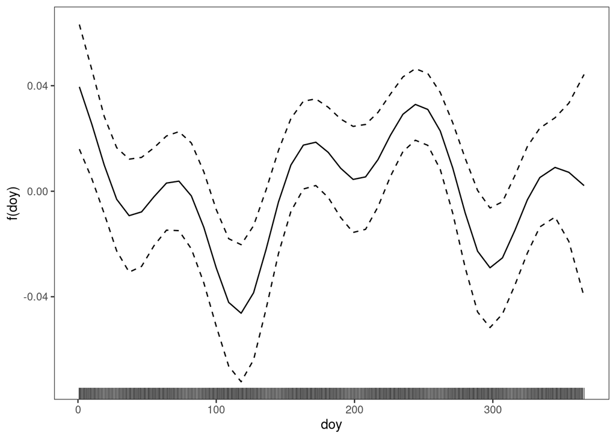

```r
plot(ALE(fit2, oind = 5, x = "doy", type = "response"))
```

Look at predictions of bi-variate Gaussian:

```r
library(mvnfast)
ii <- 1
sig_1 <- sqrt(preds[ii, 3])
sig_2 <- sqrt(preds[ii, 4])
corr_12 <- preds[ii, 5]
x     <- seq(-2, 2, length.out = 100) * max(sqrt(preds[ , 3:4]))
y     <- seq(-2, 2, length.out = 100) * max(sqrt(preds[ , 3:4]))
mu    <- c(0, 0)
sigma <- matrix(c(sig_1^2, corr_12*sig_1*sig_2, corr_12*sig_1*sig_2, sig_2^2), nrow = 2)
f     <- function(x, y) dmvn(cbind(x, y), mu, sigma)
z     <- outer(x, y, f)

contour(x, y, z, main = paste0("Day of year = ", GEF14_d4$doy[ii]),
        xlab = "Demand at 5pm", ylab = "Demand at 8pm")
```

```r
ii <- ii + 10
```

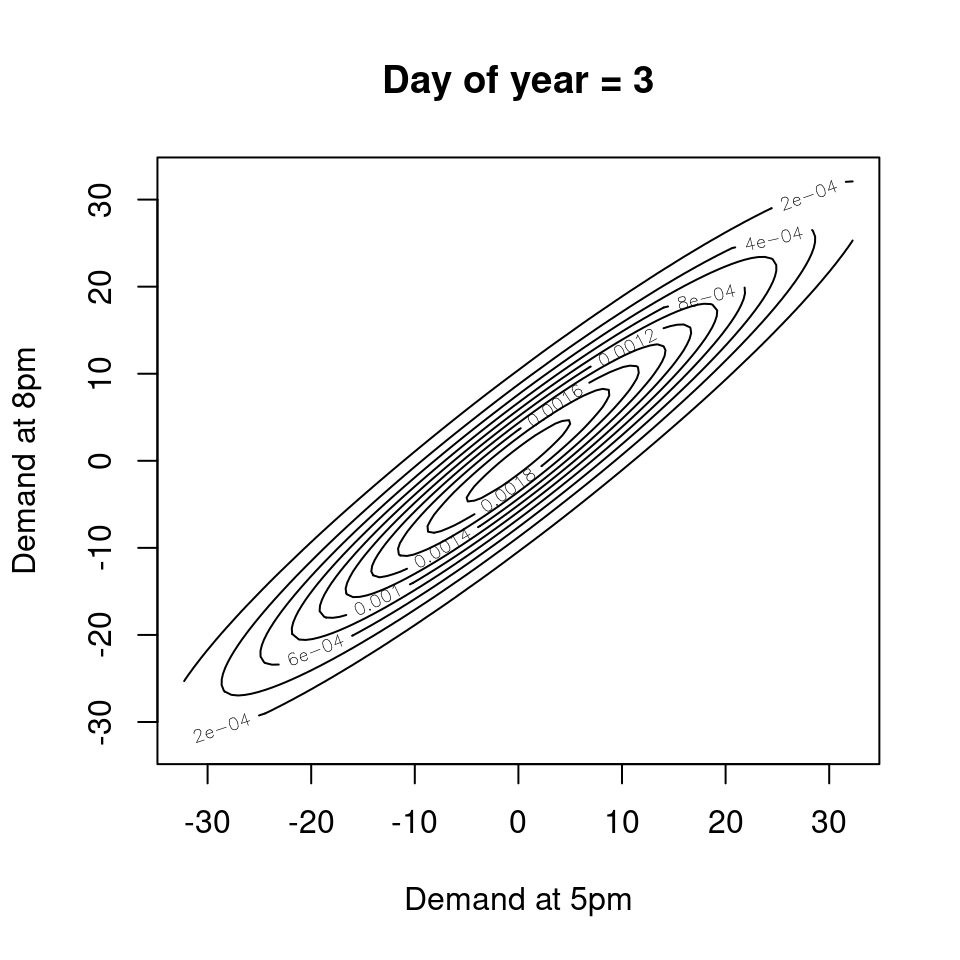

Bi-variate demand distribution (centered at zero).

# Dynamic aggregation of experts for smart meter data forecasting

Load some packages and the data:

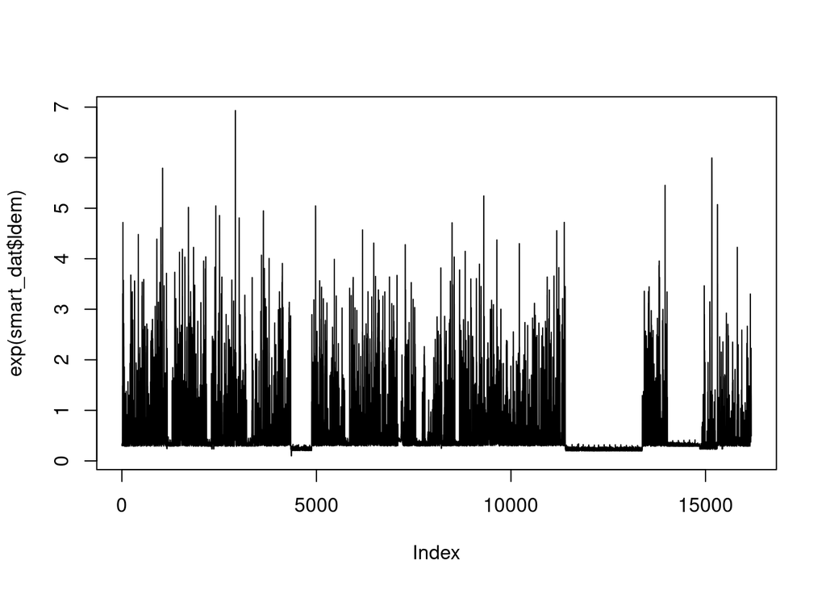

```r
library(gamFactory)
library(mgcViz)
library(dplyr)
library(magrittr)

data("smart_dat")

plot(exp(smart_dat$ldem), type = 'l')
```

Look at the data:

```r
head(round(smart_dat, 2)[ , c("ldem", "doy", "tod", "mu_g", "mu_l",
                              "lp_g", "lp_l", "mse_g_48", "mse_l_48", "test")])
```

```
##      ldem doy tod  mu_g  mu_l  lp_g  lp_l mse_g_48 mse_l_48 test
## 97  -1.14   5   1 -0.89 -0.59 -0.47 -0.82     0.19     0.29    0
## 98  -1.19   5   2 -0.96 -0.59 -0.46 -0.93     0.19     0.29    0
## 99  -1.16   5   3 -1.03 -0.59 -0.41 -0.87     0.19     0.29    0
## 100 -1.13   5   4 -1.09 -0.59 -0.39 -0.80     0.19     0.29    0
## 101 -1.11   5   5 -1.14 -0.59 -0.38 -0.77     0.19     0.29    0
## 102 -1.09   5   6 -1.16 -0.59 -0.39 -0.74     0.19     0.29    0
```

Divide into train/test:

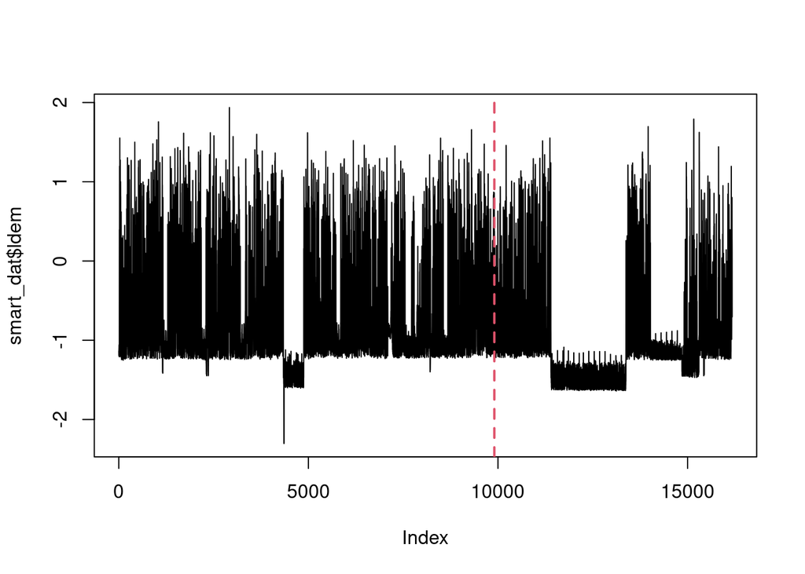

```r
train <- smart_dat[smart_dat$test == FALSE, ]
test <- smart_dat[smart_dat$test == TRUE, ]

plot(smart_dat$ldem, type = "l")
abline(v = nrow(train), lty = 2, col = 2, lwd = 2)
```

Look at experts fit on part of train set:

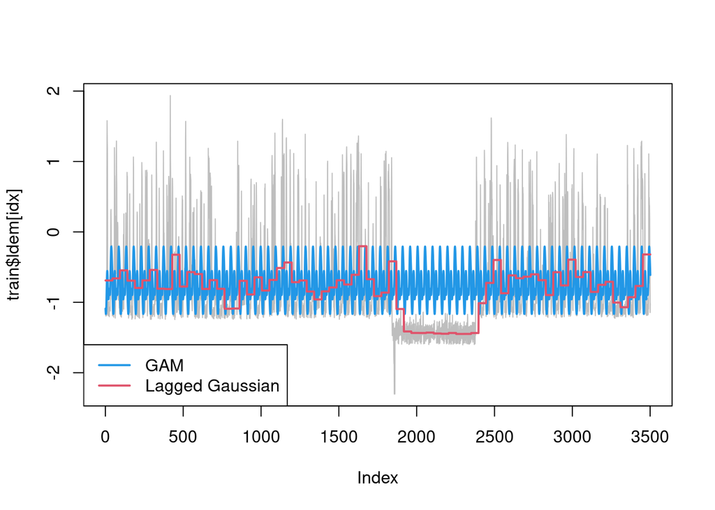

```r
idx <- 2500:6000
plot(train$ldem[idx], type = "l", col = "grey")
lines(train$mu_g[idx], col = 4, lwd = 2)
lines(train$mu_l[idx], col = 2, lwd = 2)
legend(col = c(4, 2), legend = c("GAM", "Lagged Gaussian"),
       x = "bottomleft", lty = 1, lwd = 2)
```

Fit stacking model to training set, weights depend on lagged MSEs:

```r
library(gamFactory)
library(mgcViz)
stack <- gam(list(ldem ~ s(mse_g_48, k = 5) + s(mse_l_48, k = 5)),
             family = fam_stackProb(cbind(train$lp_g, train$lp_l)),
             data = train)
stack <- getViz(stack)
```

Look at weights:

```r
head( predict(stack, type = "response") )
```

```
##          [,1]      [,2]
## 97  0.7926403 0.2073597
## 98  0.7926403 0.2073597
## 99  0.7926403 0.2073597
## 100 0.7926403 0.2073597
## 101 0.7926403 0.2073597
## 102 0.7926403 0.2073597
```

Plot accumulated local effect of lagged MSEs on the weight of GAM:

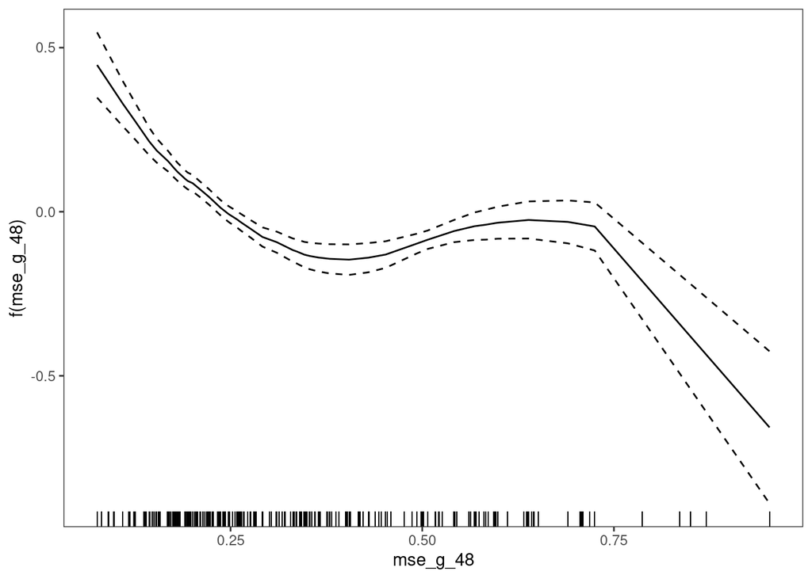

```r
plot(ALE(stack, oind = 1, x = "mse_g_48", type = "response"))
```

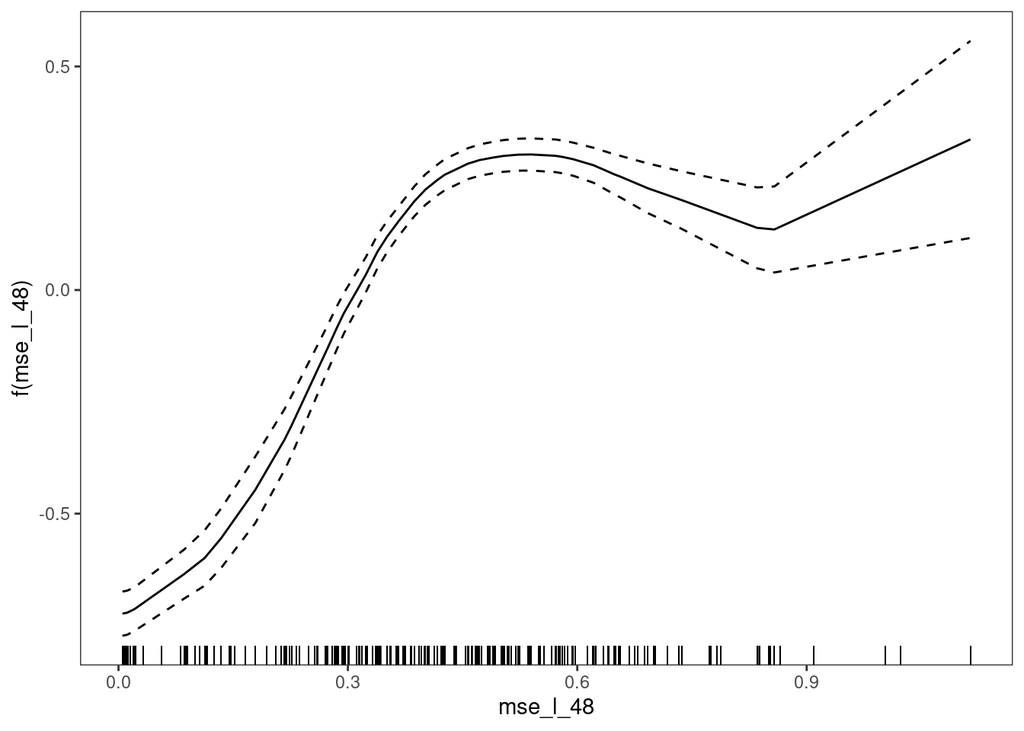

```r
plot(ALE(stack, oind = 1, x = "mse_l_48", type = "response"))
```

Predict weights on test set and get weighted predicted mean:

```r
test$weights <- predict(stack, type = "response", newdata = test)
test$mu_s <- with(test, weights[ , 1] * mu_g + weights[ , 2] * mu_l)
```

Plot predictions (top) and weights (bottom):

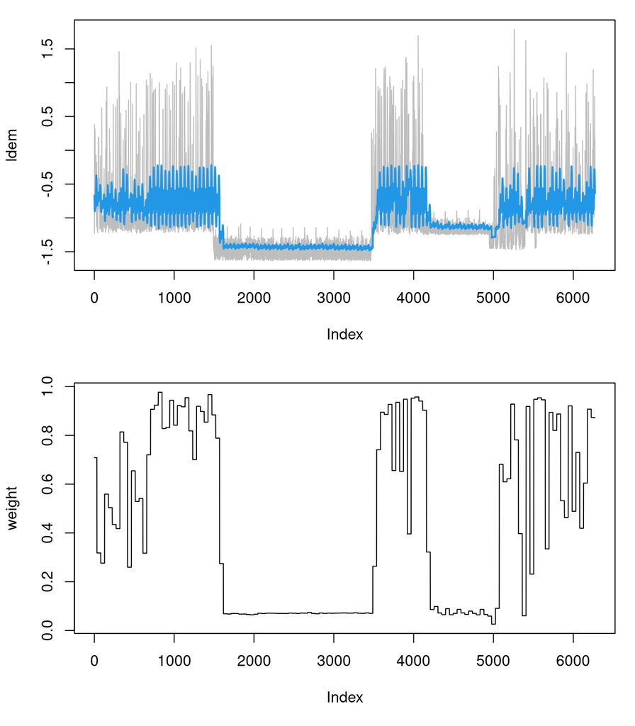

```r
par(mfrow = c(2, 1), mar = c(5.1, 4.1, 1.1, 1.1))
plot(test$ldem, type = "l", col = "grey", ylab = "ldem")
lines(test$mu_s, type = "l", col = 4, lwd = 2)
plot(test$weights[ , 1], col = 1, ylab = "weight", type = 'l')
```

Compute MSE on test set:

```r
mses <- test %>% group_by(doy) %>% summarise(mse_s = mean((ldem-mu_s)^2))
test <- test %>% left_join(mses)

colMeans(test[ , c("mse_g", "mse_l", "mse_s")])
```

```
##     mse_g     mse_l     mse_s
## 0.4168853 0.2284834 0.2000749
```